# DataVis_part2_2017-05-01.Rmd

Stacey Harmer

5/1/2017

### Section 3.6: Geometric objects

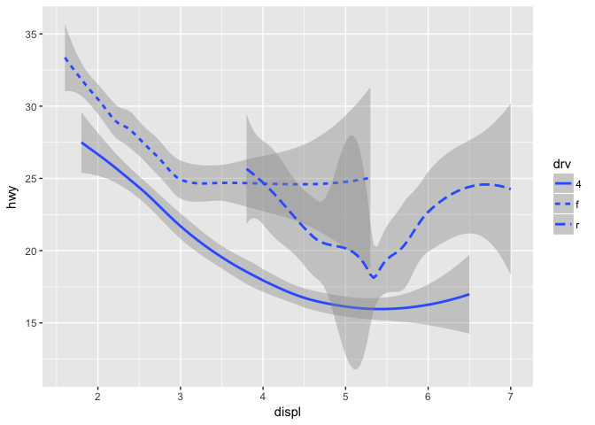

#### 3.6.1 Exercises

##### 1. What geom to draw:

linechart: geom_smooth, or geom_(ab/h/v)line, or geom_segment, or geom_spoke boxplot: geom_boxplot histogram: geom_histogram area chart: geom_area

##### 2. Predict output of code cblock.

scatterplot, hwy vs displ, colored by drive type. then a smoothed line over it fitting all the data. That last point was wrong; geom_smooth took the color by drv argument.

```r
ggplot(data = mpg, mapping = aes(x = displ, y = hwy, color = drv)) +
  geom_point() +
  geom_smooth(se = FALSE)
```

[output not shown]

##### 3. show.legend = FALSE. default is true

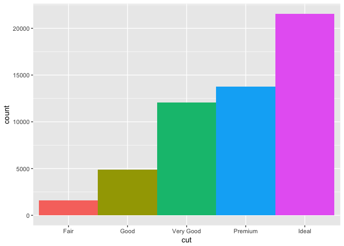

```r
ggplot(data = diamonds) +
  geom_bar(
    mapping = aes(x = cut, fill = cut),
    show.legend = FALSE,
    width = 1
  )
```

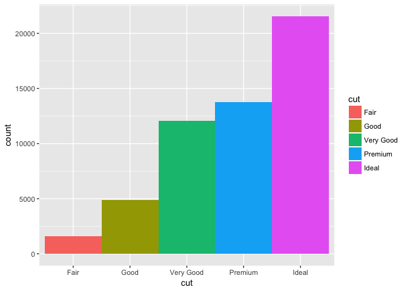

```r
#and
ggplot(data = diamonds) +
  geom_bar(
    mapping = aes(x = cut, fill = cut),
    width = 1
  )
```

##### 4. se argument for geom_smooth - adds std error interval to graph

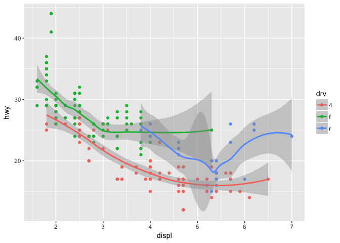

```r
ggplot(data = mpg, mapping = aes(x = displ, y = hwy, color = drv)) +
  geom_point() +
  geom_smooth(se = FALSE)
# compare to

ggplot(data = mpg, mapping = aes(x = displ, y = hwy, color = drv)) +
  geom_point() +
  geom_smooth(se = TRUE)
```

[output not shown]

##### 5. will graphs look different? No, will look the same. 2nd is just more verbose.

##### 6. Recreate R code for below

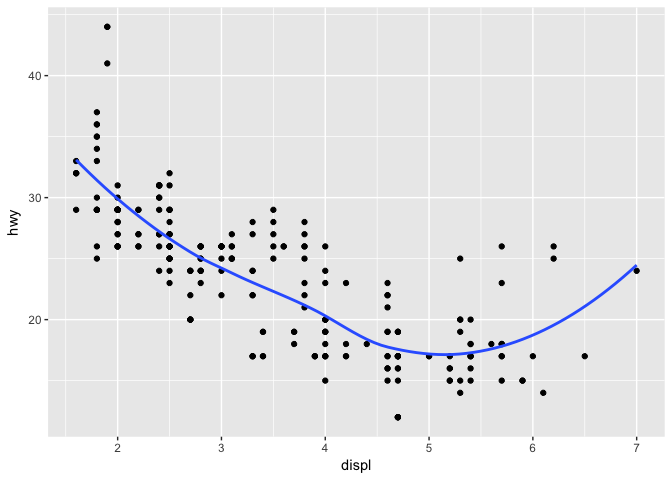

```r
# 1.
ggplot(data = mpg, mapping = aes(x = displ, y = hwy)) +
  geom_point() +
  geom_smooth(se = FALSE)
```

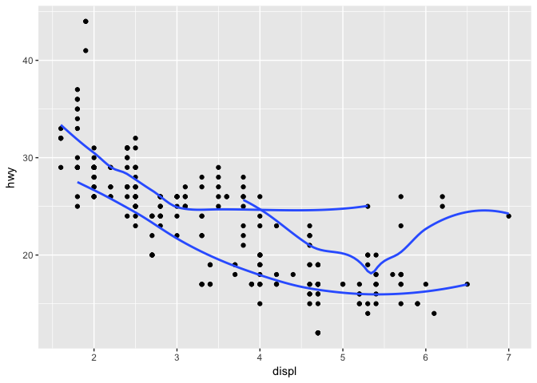

```r
# 2.
ggplot(data = mpg, mapping = aes(x = displ, y = hwy)) +
  geom_point() +
  geom_smooth(mapping = aes(group = drv), se = FALSE)
```

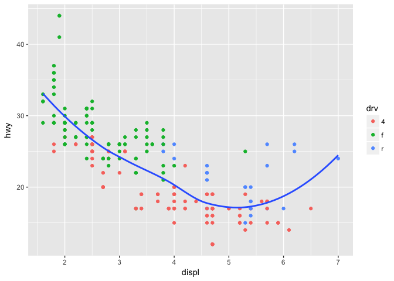

```r
# 3.
ggplot(data = mpg, mapping = aes(x = displ, y = hwy, color = drv)) +
  geom_point() +
  geom_smooth( se = FALSE)
# 4.
ggplot(data = mpg, mapping = aes(x = displ, y = hwy)) +
  geom_point(mapping = aes(color = drv)) +
  geom_smooth( se = FALSE)
```

[output not shown]

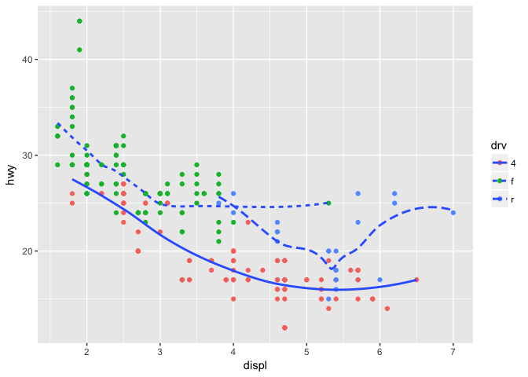

```r
# 5.
ggplot(data = mpg, mapping = aes(x = displ, y = hwy)) +
  geom_point(mapping = aes(color = drv)) +
  geom_smooth( se = FALSE, mapping = aes(linetype = drv))
```

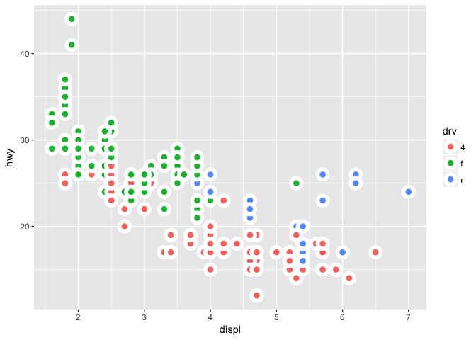

```r
# 6.
ggplot(data = mpg, mapping = aes(x = displ, y = hwy, color = drv)) +
  geom_point(mapping = aes( fill = drv), size =3, shape = 21, stroke = 3, color= "white")
```